# Comparison of functional normalization implementations

## Download example data set

> Prickett AR, Ishida M, Böhm S, Frost JM et al. Genome-wide methylation analysis in Silver-Russell syndrome patients. Hum Genet 2015 Mar;134(3):317-32. PMID: 25563730

Retrieve the data from the Gene Expression Omnibus (GEO) website (http://www.ncbi.nlm.nih.gov/geo/query/acc.cgi?acc=GSE55491).

```r
download.450k.demo.dataset <- function() {
    dir.create(path <- "data-450k-demo")

    if (length(list.files(path, "*.idat$")) == 0) {
        filename <-  file.path(path, "gse55491.tar")
        download.file("http://www.ncbi.nlm.nih.gov/geo/download/?acc=GSE55491&format=file", filename)
        cat(date(), "Extracting files from GEO archive.\n")
        system(paste("cd", path, ";", "tar xvf", basename(filename)))
        unlink(filename)
        cat(date(), "Unzipping IDAT files.\n")
        system(paste("cd", path, ";", "gunzip *.idat.gz"))

        library(GEOquery)
        geo <- getGEO("GSE55491", GSEMatrix=F)
        geo <- lapply(geo@gsms, function(gsm) unlist(gsm@header))
        geo <- do.call(rbind, geo)
        geo <- as.data.frame(geo, stringAsFactors=F)
        geo$group <- geo$characteristics_ch13
        geo$sex <-   geo$characteristics_ch11
        write.csv(geo, file=file.path(path, "samples.csv"))
    }

    path
}
```

```r
path <- download.450k.demo.dataset()
```

## Load and normalize using `minfi`

The current version `minfi::preprocessFunnorm()` contains a bug (Feb 25, 2015). To make a proper comparison with `meffil`, this bug should be fixed and `minfi` reinstalled. This can be done with the included patch file: `fix-minfi-control-matrix.patch`.

Load the data.

```r
library(minfi, quietly=TRUE)
```

Normalize using the minfi package.

```r
raw.minfi <- read.metharray.exp(base = path)
system.time(norm.minfi <- preprocessFunnorm(raw.minfi, nPCs=2,
                                            sex=NULL, bgCorr=TRUE, dyeCorr=TRUE, verbose=TRUE))
```

```
## [preprocessFunnorm] Background and dye bias correction with noob
```

```
## [preprocessFunnorm] Mapping to genome
```

```
## [preprocessFunnorm] Quantile extraction
```

```
## [preprocessFunnorm] Normalization
```

```
##    user  system elapsed
##  79.632   5.817  85.640
```

## Normalize using `meffil`

Load the code and sample filename information.

```r
library(meffil)
samplesheet <- meffil.create.samplesheet(path)
```

The package uses `mclapply` to speed up computation. Provide the number of processors available.

```r
options(mc.cores=5)
```

List the cell type references available.

```r
meffil.list.cell.type.references()
```

```
## [1] "andrews and bakulski cord blood" "blood gse35069"
## [3] "blood gse35069 chen"             "blood gse35069 complete"
## [5] "combined cord blood"             "cord blood gse68456"
## [7] "gervin and lyle cord blood"      "guintivano dlpfc"
## [9] "saliva gse48472"
```

Set parameters for the analysis.

```r
qc.file <- "minfi/qc-report.html"
author <- "Prickett, et al."
study <- "Silver-Russell syndrome patients (GEO:GSE55491)"
number.pcs <- 2
norm.file <- "minfi/normalization-report.html"
cell.type.reference <- "blood gse35069"
```

## Normalize using `meffil` step-by-step

Create QC objects for QC report and later normalization.

```r
qc.objects <- meffil.qc(samplesheet, cell.type.reference=cell.type.reference, verbose=T)
```

```
## [read.idat] Thu Jun 24 23:35:31 2021 Reading data-450k-demo/GSM1338100_6057825094_R01C01_Grn.idat
## [read.idat] Thu Jun 24 23:35:31 2021 Reading data-450k-demo/GSM1338100_6057825094_R01C01_Red.idat
## [extract.detection.pvalues] Thu Jun 24 23:35:32 2021
## [extract.beadnum] Thu Jun 24 23:35:34 2021
## [extract.snp.betas] Thu Jun 24 23:35:36 2021
## [extract.controls] Thu Jun 24 23:35:37 2021
## [background.correct] Thu Jun 24 23:35:37 2021 background correction for dye = R
## [background.correct] Thu Jun 24 23:35:39 2021 background correction for dye = G
## [dye.bias.correct] Thu Jun 24 23:35:40 2021
## [FUN] Thu Jun 24 23:35:43 2021 predicting sex
```

Create the QC report.

```r
qc.summary <- meffil.qc.summary(qc.objects, verbose=T)
meffil.qc.report(qc.summary,
                 output.file=qc.file,
                 author=author,
                 study=study)
```

Remove any samples with too many bad probes.

```r
if (nrow(qc.summary$bad.samples) > 0)
    qc.objects <- meffil.remove.samples(qc.objects, qc.summary$bad.samples$sample.name)
```

Check how many principal components to include.

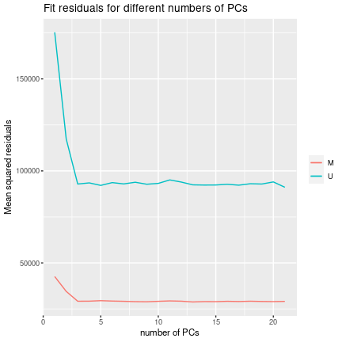

```r
print(meffil.plot.pc.fit(qc.objects)$plot)
```

```r
norm.objects <- meffil.normalize.quantiles(qc.objects, number.pcs=number.pcs, verbose=T)
```

[output not shown]

Normalize the dataset using the normalized quantiles.

```r
norm.meffil <- meffil.normalize.samples(norm.objects,
                                        just.beta=F,
                                        cpglist.remove=qc.summary$bad.cpgs$name,
                                        verbose=T)
```

```
## [read.idat] Thu Jun 24 23:38:08 2021 Reading data-450k-demo/GSM1338100_6057825094_R01C01_Grn.idat
## [read.idat] Thu Jun 24 23:38:08 2021 Reading data-450k-demo/GSM1338100_6057825094_R01C01_Red.idat
## [background.correct] Thu Jun 24 23:38:08 2021 background correction for dye = R
## [background.correct] Thu Jun 24 23:38:10 2021 background correction for dye = G
## [dye.bias.correct] Thu Jun 24 23:38:12 2021
## [meffil.normalize.sample] Thu Jun 24 23:38:13 2021 Normalizing methylated and unmethylated signals.
```

```r
beta.meffil <- meffil.get.beta(norm.meffil$M, norm.meffil$U)
```

Compute principal components of the normalized methylation matrix.

```r
pcs <- meffil.methylation.pcs(beta.meffil, sites=meffil.get.autosomal.sites("450k"), verbose=T)
```

```
## [meffil.methylation.pcs] Thu Jun 24 23:39:19 2021 Calculating CpG variance
## [meffil.methylation.pcs] Thu Jun 24 23:39:20 2021 Calculating beta PCs
```

Generate a normalization report.

```r
parameters <- meffil.normalization.parameters(norm.objects)
parameters$batch.threshold <- 0.01
norm.summary <- meffil.normalization.summary(norm.objects=norm.objects, pcs=pcs, parameters=parameters, verbose=T)
meffil.normalization.report(norm.summary,
                            output.file=norm.file,
                            author=author,
                            study=study)
```

## Compare normalizations

First make sure that the raw data is the same.

```r
raw.meffil <- meffil:::read.rg(samplesheet$Basename[1])
all(raw.meffil$R == getRed(raw.minfi)[names(raw.meffil$R),1])
```

```
## [1] TRUE
```

## Comparison of object sizes

```r
print(object.size(qc.objects), units="Mb")
```

```
## 6.2 Mb
```

```r
print(object.size(norm.objects), units="Mb")
```

```
## 7.1 Mb
```

```r
print(object.size(norm.minfi), units="Mb")
```

```
## 281.5 Mb
```

```r
print(object.size(raw.minfi), units="Mb")
```

```
## 242.2 Mb
```

### Background correction

Apply `meffil` background correction.

```r
probes <- meffil.probe.info("450k")
bc.meffil <- meffil:::background.correct(raw.meffil,probes)
M.meffil <- meffil:::rg.to.mu(bc.meffil,probes)$M
```

Apply `minfi` background correction.

```r
bc.minfi <- preprocessNoob(raw.minfi, dyeCorr = FALSE)
M.minfi <- getMeth(bc.minfi)[names(M.meffil),1]
```

Compare results, should be identical.

```r
quantile(M.meffil - M.minfi)
```

```
##   0%  25%  50%  75% 100%
##    0    0    0    0    0
```

### Dye bias correction

Apply `meffil` correction.

```r
dye.meffil <- meffil:::dye.bias.correct(bc.meffil, probes,
                                        intensity=norm.objects[[1]]$reference.intensity)
M.meffil <- meffil:::rg.to.mu(dye.meffil,probes)$M
U.meffil <- meffil:::rg.to.mu(dye.meffil,probes)$U
```

Apply `minfi` background and dye bias correction.

```r
dye.minfi <- preprocessNoob(raw.minfi, dyeCorr = TRUE)
M.minfi <- getMeth(dye.minfi)[names(M.meffil),1]
U.minfi <- getUnmeth(dye.minfi)[names(U.meffil),1]
```

```r
quantile(M.meffil - M.minfi)
```

```
##         0%        25%        50%        75%       100%
##   21.05484   86.90234  530.23319 1316.93320 6628.14159
```

```r
quantile(U.meffil - U.minfi)
```

```
##         0%        25%        50%        75%       100%
##   21.05484   87.58540  517.58028 1819.10071 6165.00887
```

```r
quantile(M.meffil/(M.meffil+U.meffil+100) - M.minfi/(M.minfi+U.minfi+100))
```

```
##           0%          25%          50%          75%         100%
## 3.271256e-06 8.059692e-05 8.401857e-04 2.039453e-03 1.733680e-02
```

### Control matrix extracted

Extract `minfi` control matrix.

```r
library(matrixStats, quietly=TRUE)
control.matrix.minfi <- minfi:::.buildControlMatrix450k(minfi:::.extractFromRGSet450k(raw.minfi))
```

Control matrix for `meffil` was extracted earlier. Preprocess the matrix using the same procedure used by `minfi`.

```r
control.matrix.meffil <- meffil.control.matrix(norm.objects)
control.matrix.meffil <- scale(control.matrix.meffil)
control.matrix.meffil[control.matrix.meffil > 3] <- 3
control.matrix.meffil[control.matrix.meffil < -3] <- -3
control.matrix.meffil <- scale(control.matrix.meffil)
```

The control variable order (columns) may be different between `minfi` and `meffil` so they are reordered.

```r
i <- apply(control.matrix.minfi,2,function(v) {
    which.min(apply(control.matrix.meffil,2,function(w) {
        sum(abs(v-w))
    }))
})
control.matrix.meffil <- control.matrix.meffil[,i]
```

Compare resulting matrices, should be identical.

```r
quantile(control.matrix.meffil - control.matrix.minfi)
```

```
##   0%  25%  50%  75% 100%
##    0    0    0    0    0
```

### Final beta values

```r
beta.minfi <- getBeta(norm.minfi)
quantile(beta.meffil - beta.minfi[rownames(beta.meffil),])
```

```
##            0%           25%           50%           75%          100%
## -0.3309599236 -0.0024066279 -0.0009762531 -0.0001480879  0.2078207424
```

On what chromosomes are the biggest differences appearing?

```r
features <- meffil.get.features("450k")
sites <- features[which(features$target == "methylation"),]
site.chromosome <- sites$chr[match(rownames(beta.meffil), sites$name)]
sex <- sapply(norm.objects, function(object) object$predicted.sex)
is.diff <- abs(beta.meffil - beta.minfi[rownames(beta.meffil),]) > 1e-4
table(site.chromosome[which(is.diff, arr.ind=T)[,"row"]])
```

```
##
##    chr1   chr10   chr11   chr12   chr13   chr14   chr15   chr16   chr17   chr18
## 1009263  533546  622267  529174  269942  326353  329315  477810  597272  125459
##   chr19    chr2   chr20   chr21   chr22    chr3    chr4    chr5    chr6    chr7
##  538370  756261  219049   91601  180566  543420  445014  529018  796733  658772
##    chr8    chr9    chrX    chrY
##  459851  219071  248913    9844
```

```r
table(site.chromosome[which(is.diff[,which(sex=="M")], arr.ind=T)[,"row"]])
```

```
##
##   chr1  chr10  chr11  chr12  chr13  chr14  chr15  chr16  chr17  chr18  chr19
## 536484 284377 331075 281345 143981 173547 175316 254281 317472  66643 285382
##   chr2  chr20  chr21  chr22   chr3   chr4   chr5   chr6   chr7   chr8   chr9
## 402817 116233  48747  95911 289460 237020 281642 423915 351021 245146 116822
##   chrX   chrY
## 127801   5293
```

```r
table(site.chromosome[which(is.diff[,which(sex=="F")], arr.ind=T)[,"row"]])
```

```
##
##   chr1  chr10  chr11  chr12  chr13  chr14  chr15  chr16  chr17  chr18  chr19
## 472779 249169 291192 247829 125961 152806 153999 223529 279800  58816 252988
##   chr2  chr20  chr21  chr22   chr3   chr4   chr5   chr6   chr7   chr8   chr9
## 353444 102816  42854  84655 253960 207994 247376 372818 307751 214705 102249
##   chrX   chrY
## 121112   4551
```

```r
autosomal.sites <- intersect(meffil.get.autosomal.sites("450k"), rownames(beta.meffil))
quantile(beta.meffil[autosomal.sites,] - beta.minfi[autosomal.sites,],na.rm=T)
```

```
##            0%           25%           50%           75%          100%
## -0.0447879181 -0.0023924705 -0.0009737661 -0.0001488759  0.0151006865
```

These are small differences relative to differences with unormalized data:

```r
beta.raw <- getBeta(raw.minfi)
quantile(beta.meffil[autosomal.sites,] - beta.raw[autosomal.sites,], na.rm=T)
```

```
##            0%           25%           50%           75%          100%
## -0.8016792686 -0.0571015164 -0.0226720225 -0.0006636376  0.2367269576
```

```r
quantile(beta.minfi[autosomal.sites,] - beta.raw[autosomal.sites,], na.rm=T)
```

```
##            0%           25%           50%           75%          100%
## -0.7962126893 -0.0559894220 -0.0212649307  0.0006700472  0.2445404023
```

In spite of the differences, CG correlations between methods are pretty close to 1.

```r
male.idx <- which(rowSums(is.diff[,sex=="M"]) >= 5)
male.cg.r <- unlist(mclapply(male.idx, function(idx) {
    cor(beta.meffil[idx, sex=="M"], beta.minfi[rownames(beta.meffil)[idx], sex=="M"])
}))
quantile(male.cg.r, probs=c(0.05,0.1,0.25,0.5))
```

```
##        5%       10%       25%       50%
## 0.9920719 0.9945526 0.9970905 0.9986170
```

```r
female.idx <- which(rowSums(is.diff[,sex=="F"]) > 0)
female.cg.r <- sapply(female.idx[1:200], function(idx) {
    cor(beta.meffil[idx, sex=="F"], beta.minfi[rownames(beta.meffil)[idx], sex=="F"])
})
quantile(female.cg.r, probs=c(0.05,0.1,0.25, 0.5))
```

```
##        5%       10%       25%       50%
## 0.7585155 0.8542710 0.9466884 0.9771569
```

## Sex

```r
sex.minfi <- as.data.frame(getSex(norm.minfi))
names(norm.objects) <- sapply(norm.objects, function(obj) basename(obj$basename))
sex.meffil <- data.frame(predicted=sapply(norm.objects, function(obj) obj$predicted.sex),
                         x.signal=sapply(norm.objects, function(obj) obj$x.signal),
                         y.signal=sapply(norm.objects, function(obj) obj$y.signal))
all(sex.minfi[rownames(sex.meffil),"predictedSex"] == sex.meffil$predicted)
```

```
## [1] TRUE
```

```r
quantile(sex.minfi[rownames(sex.meffil),"xMed"] - sex.meffil$x.signal)
```

```
##          0%         25%         50%         75%        100%
## -0.30429653  0.06473822  0.16196833  0.33830177  0.52147863
```

```r
quantile(sex.minfi[rownames(sex.meffil),"yMed"] - sex.meffil$y.signal)
```

```
##          0%         25%         50%         75%        100%
## -0.30429672  0.06473816  0.16196839  0.33830185  0.52147863
```

## Cell count estimates

```r
counts.meffil <- t(meffil.cell.count.estimates(norm.objects))
```

```r
require("FlowSorted.Blood.450k")
counts.minfi <- estimateCellCounts(raw.minfi)
```

```
## [estimateCellCounts] Combining user data with reference (flow sorted) data.
```

```
## [estimateCellCounts] Processing user and reference data together.
```

```
## [preprocessQuantile] Mapping to genome.
```

```
## [preprocessQuantile] Fixing outliers.
```

```
## [preprocessQuantile] Quantile normalizing.
```

```
## [estimateCellCounts] Picking probes for composition estimation.
```

```
## [estimateCellCounts] Estimating composition.
```

```r
counts.minfi <- counts.minfi[rownames(counts.meffil), colnames(counts.meffil)]
```

```r
sapply(rownames(counts.meffil), function(i) cor(counts.meffil[i,], counts.minfi[i,]))
```

```
## GSM1338100_6057825094_R01C01 GSM1338101_6057825094_R01C02
##                    0.9596537                    0.9950504
## GSM1338102_6057825094_R02C01 GSM1338103_6057825094_R02C02
##                    0.9044225                    0.9781157
## GSM1338104_6057825094_R03C01 GSM1338105_6057825094_R03C02
##                    0.9939169                    0.9703330
## GSM1338106_6057825094_R04C01 GSM1338107_6057825094_R04C02
##                    0.9472517                    0.9966981
## GSM1338108_6057825094_R05C01 GSM1338109_6057825094_R05C02
##                    0.9194064                    0.9900985
## GSM1338110_6057825094_R06C01 GSM1338111_6057825094_R06C02
##                    0.9772307                    0.9951045
## GSM1338112_6057825116_R01C01 GSM1338113_6057825116_R01C02
##                    0.9840887                    0.9925074
## GSM1338114_6057825116_R02C01 GSM1338115_6057825116_R02C02
##                    0.9836261                    0.9992206
## GSM1338116_6057825116_R03C01 GSM1338117_6057825116_R03C02
##                    0.9843422                    0.9836710
## GSM1338118_6057825116_R04C01 GSM1338119_6057825116_R04C02
##                    0.9585215                    0.9828932
## GSM1338120_6057825116_R05C01 GSM1338121_6057825116_R05C02
##                    0.9498975                    0.9659665
## GSM1338122_6057825116_R06C01 GSM1338123_6057825116_R06C02
##                    0.9887537                    0.9815153
```

```r
sapply(colnames(counts.meffil), function(i) cor(counts.meffil[,i], counts.minfi[,i]))
```

```
##     Bcell      CD4T      CD8T      Gran      Mono        NK
## 0.9986551 0.9849118 0.9633026 0.9965621 0.9517051 0.8855715
```

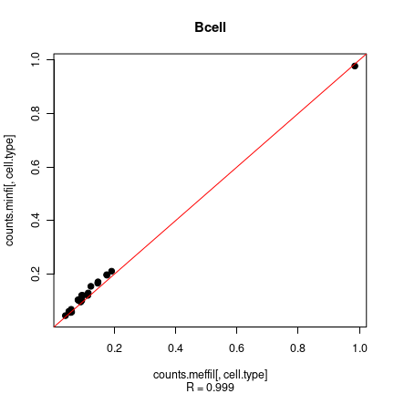

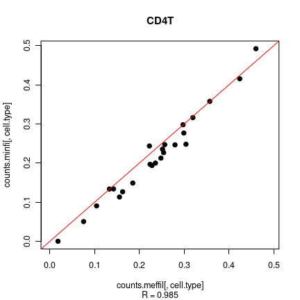

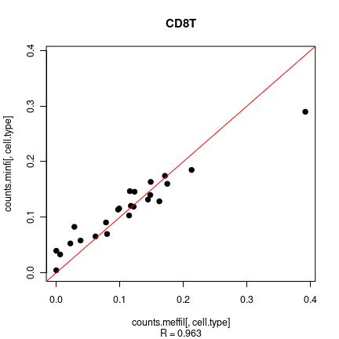

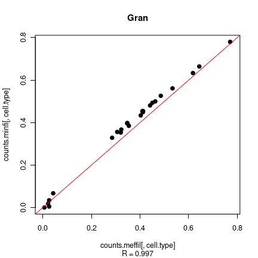

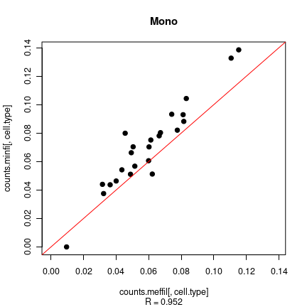

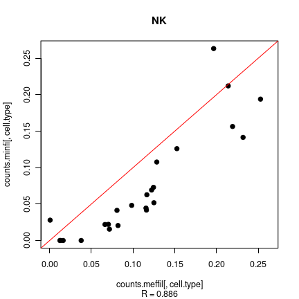

```r
for (cell.type in colnames(counts.meffil)) {
    lim <- range(c(counts.meffil[,cell.type], counts.minfi[,cell.type]))
    plot(counts.meffil[,cell.type], counts.minfi[,cell.type], pch=19,
         main=cell.type,
         sub=paste("R =", format(cor(counts.meffil[,cell.type], counts.minfi[,cell.type]), digits=3)),
         xlim=lim,ylim=lim)
    abline(a=0,b=1,col="red")
}
```

```r
counts.beta <- meffil.estimate.cell.counts.from.betas(beta.meffil, cell.type.reference)
```

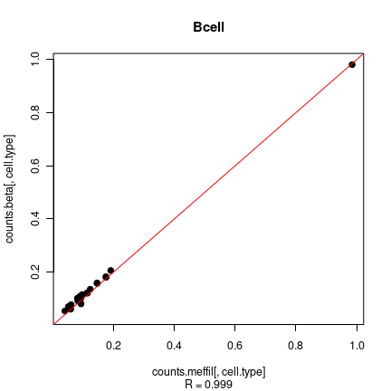

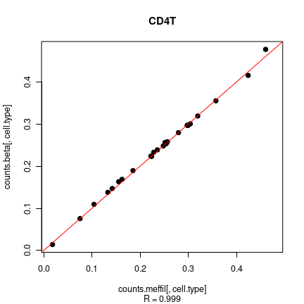

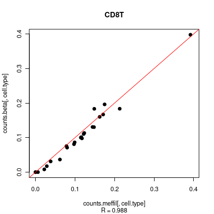

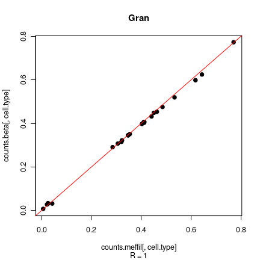

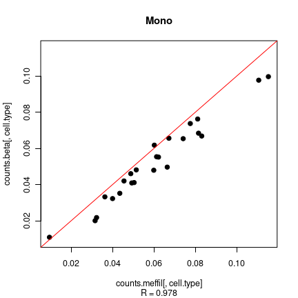

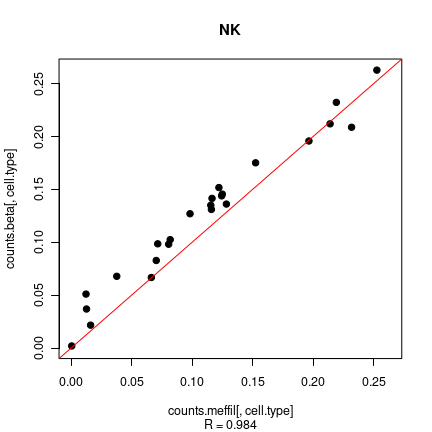

```r
for (cell.type in colnames(counts.meffil)) {
    lim <- range(c(counts.meffil[,cell.type], counts.beta[,cell.type]))
    plot(counts.meffil[,cell.type], counts.beta[,cell.type], pch=19,
         main=cell.type,
         sub=paste("R =", format(cor(counts.meffil[,cell.type], counts.beta[,cell.type]), digits=3)),
         xlim=lim,ylim=lim)
    abline(a=0,b=1,col="red")
}
```

## SNP signals

```r
snps.meffil <- meffil.snp.betas(qc.objects)
snps.minfi <- getSnpBeta(raw.minfi)
quantile(snps.meffil - snps.minfi[rownames(snps.meffil),])
```

```
##   0%  25%  50%  75% 100%
##    0    0    0    0    0
```